# 前言

**价量相关性的平均数因子**：平均数因子利用成交量的信息，修正了传统 反转因子对股票价格涨跌的判断，即价格涨跌的反转不完全由价格自己 决定，还需看成交量的信息，若有量的确认，则月度行情的反转效应更强；若没有量的确认，则月度行情更容易呈现动量效应。

**价量相关性的波动性因子**：波动性因子则从价量形态稳定性的角度，对 反转因子进行了改进，即无论股票价格过去的涨跌，只要每日价量关系 维持某种稳定形态，下个月就更有可能上涨；而价量关系在多种形态间频繁切换的股票，下个月更有可能下跌。

**价量相关性的趋势因子**：股票价量相关性的变化趋势中也包含了有效的 选股信号。回测结果显示，价量相关系数随时间推移变小的股票，下个月的收益倾向于越高。

```python
# 引入库
import sys

sys.path.append('../..')

from Hugos_tools.Tdays import (Tdaysoffset, get_trade_period)
from Hugos_tools.BuildStockPool import Filter_Stocks
from Hugos_tools.Stragegy_performance import (get_performance_table,
                                              get_information_table,
                                              calc_mono_score)
import functools
import warnings
from typing import (List, Tuple, Dict, Callable, Union)
from tqdm import tqdm_notebook

import alphalens as al
import alphalens.performance as perf
import statsmodels.api as sm
from scipy.stats import pearsonr
import pandas as pd
import numpy as np
import empyrical as ep

from jqdata import *
from jqfactor import (calc_factors, Factor)

import seaborn as sns
import matplotlib as mpl
import matplotlib.pyplot as plt

plt.rcParams['font.sans-serif'] = ['SimHei']  #用来正常显示中文标签
plt.rcParams['axes.unicode_minus'] = False  #用来正常显示负号
```

# 价量相关性因子的构建

经过探索，我们找到一种提炼有效信息的方案，以全体A股为研究样本（剔除其中的ST股、停牌股以及上市不足60个交易日的次新股），以 2014/01/01-2021/11/30为回测时间段，实施以下操作：

1. 每月月底，回溯每只股票过去 20 个交易日的价量信息，每日计算该股票分钟收盘价与分钟成交量的相关系数；
2. 每只股票取 20 日相关系数的平均值，做横截面市值中性化处理，将得到的结果记为平均数因子 PV_corr_avg；
3. 每只股票取 20 日相关系数的标准差，同样做市值中性化处理，将结果记为波动性因子 PV_corr_std；
4. 采用最简单的方式综合上述两个因子的信息，将 PV_corr_avg 和 PV_corr_std分别横截面标准化，等权线性相加得到价量相关性综合因子 PV_corr，即

$$PV\_corr = \frac{PV\_corr\_avg-mean(PV\_corr\_avg)}{std(PV\_corr_avg)}+\frac{PV\_corr\_std-mean(PV\_corr\_std)}{std(PV\_corr\_std)}$$

## 价量相关性因子的逻辑

### 平均数因子

先来看平均数因子 PV_corr_avg，它衡量了股票过去 20 日价量相关性的平均水平， 回测结果显示，**价量相关系数越小的股票，未来收益倾向于越高。**经过反复推敲，我们认为该因子其实是对传统反转因子做了修正。入下图，传统反转因子认为，股票的月度行情存在反转效应，过去 20 日上涨的股票下个月更倾向于下跌，应该归于空头； 而过去 20 日下跌的股票未来更有可能上涨，下个月应该归为多头。**价量相关性的平均数因子 PV_corr_avg 则加入量的信息，细化了反转因子对股票价格形态的分类。**

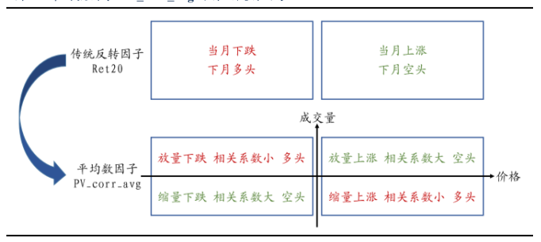

对于价格上涨，可以进一步分为放量上涨和缩量上涨，前者的价量相关系数较大， 后者的价量相关系数较小，在 PV_corr_avg 因子看来，两者不可混为一谈。过去放量上 涨的股票，就好比武侠小说中的“末路英雄”，强弩之末，难穿鲁缟，耗尽了内力，下 个月便倾向于下跌，这一点与反转因子一致；而过去缩量上涨的股票，好比有绵绵内力 不断缓缓释放，上个月还未涨到尽头，仍有力量支撑，下个月便能延续之前的行情，继续上涨，这一点正好与反转因子相反。

对于价格下跌，也可以进一步分为放量下跌和缩量下跌，前者的价量相关系数小， 后者的价量相关系数大，PV_corr_avg 因子对这两类股票也持有不同的态度。放量下跌 的股票，PV_corr_avg 的判断与反转因子一致，认为下个月行情更容易反转，归为多头； 而过去平均来看缩量下跌的股票，由于还未经历放量见底的过程，下个月的反转行情相对较弱，仍然归于空头，这一点与反转因子不同。

综上所述，平均数因子 PV_corr_avg 对传统反转因子的修正逻辑可总结为：**价格涨跌的反转不完全由价格自己决定，还需看成交量的信息，若有量的确认，则月度行情的反转效应更强；若没有量的确认，则月度行情的动量效应更强。**

### 波动性因子

再来看衡量股票过去价量相关性波动情况的 PV_corr_std 因子，回测结果显示，因 子值越小，股票未来收益越高。我们也分 4 种价量关系分析该因子的选股逻辑。

对于缩量上涨和放量下跌的情形，若股票的价量相关系数波动较小，则意味着股票在过去 20 个交易日，每日都稳定呈现缩量上涨或放量下跌的形态，自然与 PV_corr_avg因子的判断一致，将股票归为多头。

而对另外两种情形的分析，PV_corr_std因子则与PV_corr_avg不同。对于放量上涨， 若价量相关系数波动较小，则意味着股票过去 20 个交易日，每日都呈现放量上涨的状 态，此时它不再是“末路英雄”，而是“绝顶高手”，比如受到了众多利好信息的持续刺 激，这类股票下个月应该仍然归为多头，期待上涨行情得以延续；对于缩量下跌，若股 票每日都稳定呈现此状态，则 PV_corr_std 因子对该股的判断与反转因子相同，认为下个月更有可能反转，出现上涨行情。

其实，**波动性因子 PV_corr_std 包含的选股信息也可以看做是对反转因子的一种修 正：无论股票过去是上涨还是下跌，只要每日价量关系维持一种稳定的形态， PV_corr_std 因子就把这只股票归为未来的多头；而价量关系在多种形态间频繁转换的股票，就会被 PV_corr_std 因子归为空头。**

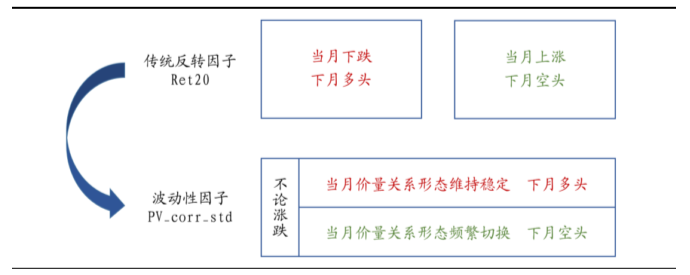

**小结**

总结了前两部分的分析，价量相关性因子可以看做是对传统反转的修正。

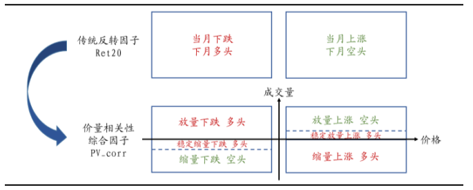

由上，pv_corr可以看作是对传统反转因子的修正，价量相关性因子的选股信息必然与传统反转存在重叠。我们可进一步精炼选股信息，先**将两个子因子PV_corr_avg和PV_corr_std 分别剔除反转因子，再各自横截面标准化，等权线性相加构建综合因子，将得到的新因子记为 PV_corr_deRet20。**

# 趋势因子的增量信息

在前文研究的基础上，我们额外发现股票价量相关性的变化趋势也能带来一些增量 信息，因此本节内容做进一步探索，挖掘新信息，并在最后呈现包含价量相关性3个维度信息的最终因子。

## 价量相关性的趋势因子

本节介绍的选股因子计算过程如下：

1. 每月月底，仍然回溯每只股票过去 20 个交易日的价量信息，每日计算该股票分钟收盘价与分钟成交量的相关系数；
2. 将每只股票的 20 个相关系数𝜌𝑡对时间𝑡回归，取回归系数𝛽，即𝜌𝑡 = 𝛽 ∗ 𝑡 + 𝜀𝑡，其中，𝑡取值为 1,2,3,……,20；
3. 将所有股票的回归系数𝛽在横截面上剔除市值、传统价量类因子（20 日反转、20 日换手率、20 日波动率因子），将得到的结果定义为趋势因子 PV_corr_trend。

## 最终的价量相关性因子——CPV

经检验，上一小节介绍的趋势因子 PV_corr_trend 在剔除原来的综合因子 PV_corr_deRet20 后，仍然具有一定的选股能力，因此我们将 PV_corr_trend 带来的增量 信息叠加到 PV_corr_deRet20 之上，最终因子命名为CPV因子（Correlation of Price and Volume），涵盖了本篇报告提出的价量相关性 3 个维度上的综合信息：

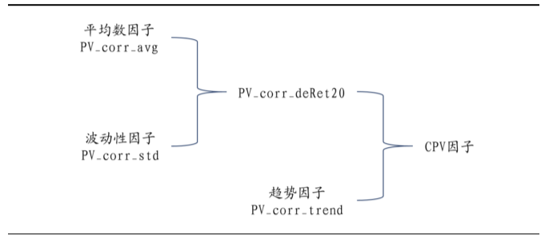

```python
"""因子构建相关"""
# 修饰器-分钟及数据数量大用次部分进行拆分


def split_securities(Limit: int = 500):
    def decorator(func: Callable):
        @functools.wraps(func)
        def wrapper(*args, **kw):

            if 'securities' not in kw:

                securities = args[0]

                args = args[1:]

            else:

                securities = kw['securities']

                del kw['securities']

            if isinstance(securities, str):

                securities = [securities]

            size = len(securities)

            if size > Limit:

                return pd.concat((func(securities[i:i + Limit], *args, **kw)
                                  for i in range(0, size, Limit)))

            else:

                return func(securities, *args, **kw)

        return wrapper

    return decorator

# 获取日内数据


@split_securities()
def get_intraday_price(securities: Union[str, List], end_date: str,
                       count: int) -> pd.DataFrame:
    """获取日内分钟数据

    Args:
        securities (Union[str, List]): 标的
        end_date (str): 观察日
        count (int): 天数

    Returns:
        pd.DataFrame: 数据
    """
    return get_price(securities,
                     end_date=end_date + ' 15:00:00',
                     count=240 * count,
                     frequency='1m',
                     fields=['close', 'volume'],
                     panel=False)


# 计算相关系数
def calc_corr(price: pd.DataFrame) -> pd.Series:
    """计算量价相关系数

    Args:
        price (pd.DataFrame): 量价数据，index-datetime

    Returns:
        pd.Series: 相关系数
    """
    group = price.index.normalize()

    return price.groupby(price.index.normalize()).apply(
        lambda x: pearsonr(x['close'], x['volume'])[0])


# 计算标准分
def scaling_z_score(ser: pd.Series) -> pd.Series:
    """标准分

    Args:
        ser (pd.Series): 因子值

    Returns:
        pd.Series: 标准化后的因子
    """
    return (ser - ser.mean()) / ser.std()


# 计算残差
def calc_ols(x: pd.Series, y: pd.Series,
             method: str = 'resid') -> pd.Series:
    """计算回归

    Args:
        x (pd.Series): 自变量
        y (pd.Series): 应变量

    Returns:
        pd.Series: 残差
    """

    result = sm.OLS(y.fillna(0), sm.add_constant(np.nan_to_num(x))).fit()

    return getattr(result, method)


def Culling_factor(factor_ser: pd.Series,
                   other_factor: Union[pd.Series, pd.DataFrame],
                   scaling: bool = True) -> pd.Series:
    """计算剔除其他因子

    再各自横截面标准化，等权线性相加构建综合因子
    Args:
        factor_ser (pd.Series): 因子
        other_factor (pd.Series|pd.DataFrame): 反转因子
        scaling (bool):是否标准化
    Returns:
        pd.DataFrame: 结果
    """

    # 去除反转因子的影响
    ser = calc_ols(other_factor, factor_ser, 'resid')

    if scaling:
        # 标准化
        scaling_ser = scaling_z_score(ser)

    else:

        scaling_ser = ser

    return scaling_ser


@split_securities()
def calc_pv_corr(securities: Union[list, str], end_date: str, count: int,
                 market_cap: pd.Series) -> pd.DataFrame:
    """计算因子

    Args:
        securities (Union[list, str]): 标的
        end_date (str): 观察日
        count (int): 周期
        market_cap (pd.Series): 市值数据

    Returns:
        pd.DataFrame: 因子
    """
    # 获取分钟数据
    price = get_intraday_price(securities, end_date=end_date, count=count)
    # 获取量价相关系数
    pv_corr = (price.set_index('time').groupby('code').apply(calc_corr).T)

    # 计算pv_corr_trend所需的回归系数

    pv_beta = pv_corr.apply(lambda x: calc_ols(np.arange(1,
                                                         len(x) + 1), x,
                                               'params')[1])  # 这里只是中间过程

    # 平均数因子
    pv_corr_avg = pv_corr.mean()
    # 波 动性因子
    pv_corr_std = pv_corr.std()

    # 市值-标准化处理
    market_cap = scaling_z_score(market_cap.loc[securities])
    # 市值中性化
    pv_corr_avg = Culling_factor(pv_corr_avg, market_cap, False)
    pv_corr_std = Culling_factor(pv_corr_std, market_cap, False)
    pv_beta = Culling_factor(pv_beta, market_cap, False)

    pv_corr = scaling_z_score(pv_corr_avg) + scaling_z_score(pv_corr_std)

    df = pd.concat((pv_corr_avg, pv_corr_std, pv_corr, pv_beta), axis=1)
    df.columns = ['pv_corr_avg', 'pv_corr_std', 'pv_corr', 'pv_corr_trend']

    return df


class PV_corr(Factor):

    warnings.filterwarnings("ignore")
    name = 'PV_corr'
    max_window = 20  # 可做敏感分析
    # ROC20-20日动量
    # VOL20-20日换手率
    # 聚宽居然木有波动率....
    dependencies = ['market_cap', 'ROC20', 'VOL20', 'close']

    def calc(self, data: Dict) -> pd.Series:

        codes = data['market_cap'].columns.tolist()
        tradeDate = data['market_cap'].index[-1].strftime('%Y-%m-%d')
        market_cap = data['market_cap'].iloc[-1]

        # 获取反转因子
        volatility: pd.Series = data['close'].pct_change().std()  # 计算20日波动率
        roc: pd.Series = data['ROC20'].iloc[-1]
        vol: pd.Series = data['VOL20'].iloc[-1]
        other_factor: pd.DataFrame = pd.concat((roc, vol, volatility), axis=1)
        # 反转因子标准化
        other_factor = other_factor.apply(scaling_z_score)

        df = calc_pv_corr(securities=codes,
                          end_date=tradeDate,
                          count=self.max_window,
                          market_cap=market_cap)

        # 计算pv_corr_deret20
        pv_corr_avg_: pd.Series = Culling_factor(df['pv_corr_avg'],
                                                 other_factor, True)

        pv_corr_std_: pd.Series = Culling_factor(df['pv_corr_std'],
                                                 other_factor, True)

        df['pv_corr_deret20'] = pv_corr_avg_ + pv_corr_std_

        # 计算pv_corr_trend
        df['pv_corr_trend'] = Culling_factor(df['pv_corr_trend'], other_factor,
                                             False)

        df['CPV'] = scaling_z_score(df['pv_corr_deret20']) + scaling_z_score(
            df['pv_corr_trend'])

        self.market_cap: pd.Series = market_cap
        self.other_factor: pd.DataFrame = other_factor
        self.pv_corr_factor: pd.DataFrame = df


"""因子获取"""


def get_factor(symbol: str, tradeDt) -> pd.DataFrame:
    """获取因子

    Args:
        symbol (str): 股票池范围 A为全A
        startDate (str): 起始日期
        endDate (str): 结束日期
        freq (str): 频率

    Returns:
        pd.DataFrame: 因子
    """

    for tradeDt in tqdm_notebook(periods, desc='因子获取'):

        stock_pool_func = Filter_Stocks(symbol, tradeDt)
        stock_pool_func.filter_paused(21, 20)  # 过滤21日停牌超过20日的股票
        stock_pool_func.filter_st()  # 过滤st
        stock_pool_func.filter_ipodate(60)  # 过滤次新

        PV_CORR = PV_corr()
        codes = stock_pool_func.securities
        calc_factors(codes, [PV_CORR], start_date=tradeDt, end_date=tradeDt)
        yield PV_CORR.pv_corr_factor


def get_freq_price(security: Union[List, str], periods: List) -> pd.DataFrame:
    """获取对应频率价格数据

    Args:
        security (Union[List, str]): 标的
        periods (List): 频率

    Yields:
        Iterator[pd.DataFrame]
    """
    for trade in tqdm_notebook(periods, desc='获取收盘价数据'):

        yield get_price(security,
                        end_date=trade,
                        count=1,
                        fields='close',
                        fq='post',
                        panel=False)


def get_pricing(factor_df: pd.DataFrame, last_periods: str = None) -> pd.DataFrame:
    """获取价格数据

    Args:
        factor_df (pd.DataFrame): 因子数据  MultiIndex levels-0 date levels-1 code
        last_periods (str, optional): 最后一期数据. Defaults to None.

    Returns:
        pd.DataFrame
    """
    if last_periods is not None:
        periods = factor_df.index.levels[0].tolist(
        ) + [pd.to_datetime(last_periods)]
    else:
        periods = factor_df.index.levels[0]

    securities = factor_df.index.levels[1].tolist()

    # 获取收盘价
    price_list = list(get_freq_price(securities, periods))
    price_df = pd.concat(price_list)
    pivot_price = pd.pivot_table(price_df,
                                 index='time',
                                 columns='code',
                                 values='close')
    return pivot_price


class get_factor_returns(object):

    def __init__(self, factors: pd.DataFrame, factor_name: str, max_loss: float) -> None:
        '''
        输入:factors MuliIndex level0-date level1-asset columns-factors
        '''
        self.factors = factors
        self.factor_name = factor_name
        self.name = self.factor_name
        self.max_loss = max_loss

    def get_calc(self, pricing: pd.DataFrame, periods: Tuple = (1,), quantiles: int = 5) -> pd.DataFrame:

        factor_ser: pd.Series = self.factors[self.factor_name]
        preprocessing_factor = al.utils.get_clean_factor_and_forward_returns(factor_ser,
                                                                             pricing,
                                                                             periods=periods,
                                                                             quantiles=quantiles,
                                                                             max_loss=self.max_loss)

        # 预处理好的因子
        self.factors_frame = preprocessing_factor

        # 分组收益
        self.group_returns = pd.pivot_table(preprocessing_factor.reset_index(
        ), index='date', columns='factor_quantile', values=1)

        # 分组累计收益
        self.group_cum_returns = ep.cum_returns(
            self.group_returns)

    def long_short(self, lower: int = 1, upper: int = 5) -> pd.Series:
        '''
        获取多空收益
        默认地分组为1,高分组为5
        '''
        try:
            self.group_returns
        except NameError:
            raise ValueError('请先执行get_calc')

        self.long_short_returns = self.group_returns[upper] - \
            self.group_returns[lower]
        self.long_short_returns.name = f'{self.name}_excess_ret'

        self.long_short_cum = ep.cum_returns(self.long_short_returns)
        self.long_short_cum.name = f'{self.name}_excess_cum'
```

```python
# 因子获取
periods = get_trade_period('2014-01-01', '2021-10-31', 'ME')
factor_dfs = list(get_factor('A', periods))

# 因子值
factor_df = pd.concat({tradeDt: df for tradeDt, df in zip(
    periods, factor_dfs)}, names=['date', 'asset'])

# 数据储存
factor_df.to_csv('cpv.csv')
```

```python
# 读取
factor_df = pd.read_csv('cpv.csv',index_col=[0,1],parse_dates=['date'])

# 获取收盘价数据
pricing = get_pricing(factor_df, '2021-11-30')
```

```python
# 数据结构如下
factor_df.tail()
```

| date | asset | pv_corr_avg | pv_corr_std | pv_corr | pv_corr_trend | pv_corr_deret20 | CPV |
| --- | --- | --- | --- | --- | --- | --- | --- |
| 2021-10-29 | 688799.XSHG | -0.040364 | -0.059105 | -2.062111 | 0.003719 | -1.530446 | -0.588403 |
|  | 688800.XSHG | -0.044931 | 0.062279 | 0.593672 | 0.004973 | -1.193098 | -0.217781 |
|  | 688819.XSHG | 0.022162 | 0.007419 | 0.567500 | 0.006496 | 0.947565 | 1.386607 |
|  | 688981.XSHG | -0.035503 | -0.117590 | -3.293693 | -0.002650 | -2.185112 | -1.765053 |
|  | 689009.XSHG | -0.017115 | 0.057875 | 0.996562 | -0.003718 | 0.413937 | -0.155996 |

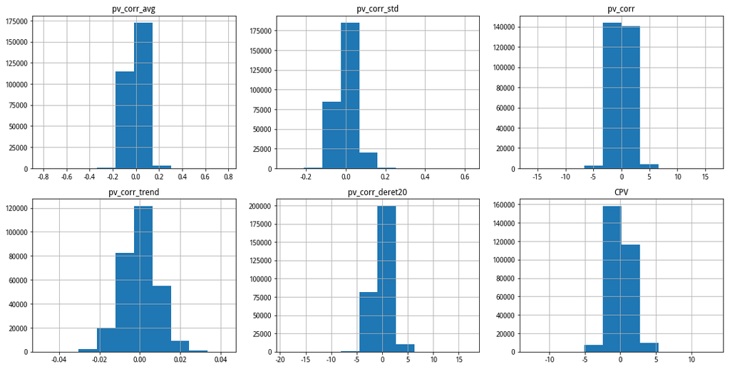

```python
# 查看因子分布
fig, axes = plt.subplots(2, 3, figsize=(18, 9))

axes = [i for x in axes for i in x]
for ax, (name, ser) in zip(axes, factor_df.items()):

    ax.set_title(name)
    ser.hist(ax=ax)
```

```python
# 获取因子回测数据
factor_name = factor_df.columns.tolist()
res_dic = {}

for ax, name in zip(axes, factor_name):

    res = get_factor_returns(factor_df, name, 0.4)
    res.get_calc(pricing)
    res.long_short(5, 1)
    res_dic[name] = res
```

```
Dropped 0.0% entries from factor data (0.0% after in forward returns computation and 0.0% in binning phase). Set max_loss=0 to see potentially suppressed Exceptions.
Dropped 0.0% entries from factor data (0.0% after in forward returns computation and 0.0% in binning phase). Set max_loss=0 to see potentially suppressed Exceptions.
Dropped 0.0% entries from factor data (0.0% after in forward returns computation and 0.0% in binning phase). Set max_loss=0 to see potentially suppressed Exceptions.
Dropped 0.0% entries from factor data (0.0% after in forward returns computation and 0.0% in binning phase). Set max_loss=0 to see potentially suppressed Exceptions.
Dropped 0.0% entries from factor data (0.0% after in forward returns computation and 0.0% in binning phase). Set max_loss=0 to see potentially suppressed Exceptions.
Dropped 0.0% entries from factor data (0.0% after in forward returns computation and 0.0% in binning phase). Set max_loss=0 to see potentially suppressed Exceptions.
```

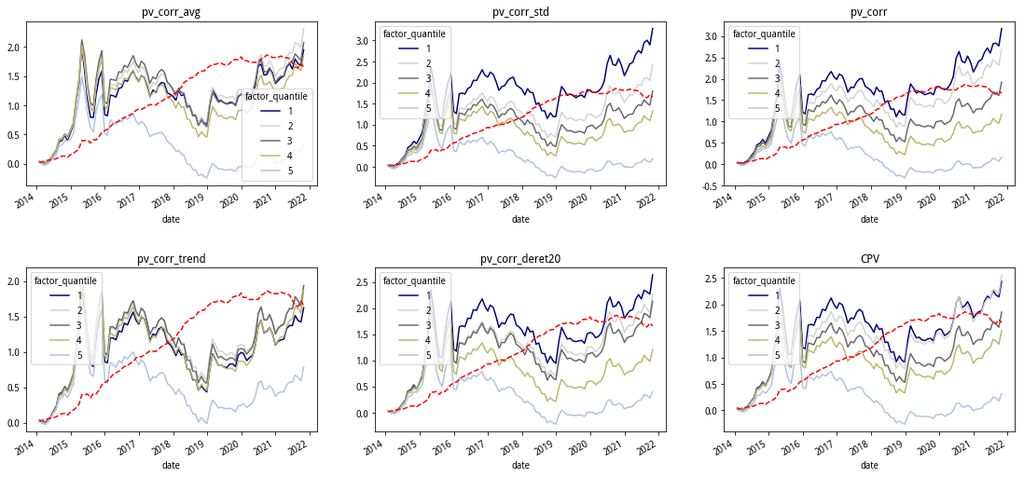

```python
# 因子分组收益
fig, axes = plt.subplots(2, 3, figsize=(19, 9))
axes = [i for x in axes for i in x]
for ax,(k,v) in zip(axes,res_dic.items()):
    v.group_cum_returns.plot(
        ax=ax,
        title=k,
        color=['Navy', 'LightGrey', 'DimGray', 'DarkKhaki', 'LightSteelBlue'])
    res.long_short_cum.plot(ax=ax, ls='--', color='red')

plt.subplots_adjust(hspace=0.5)
```

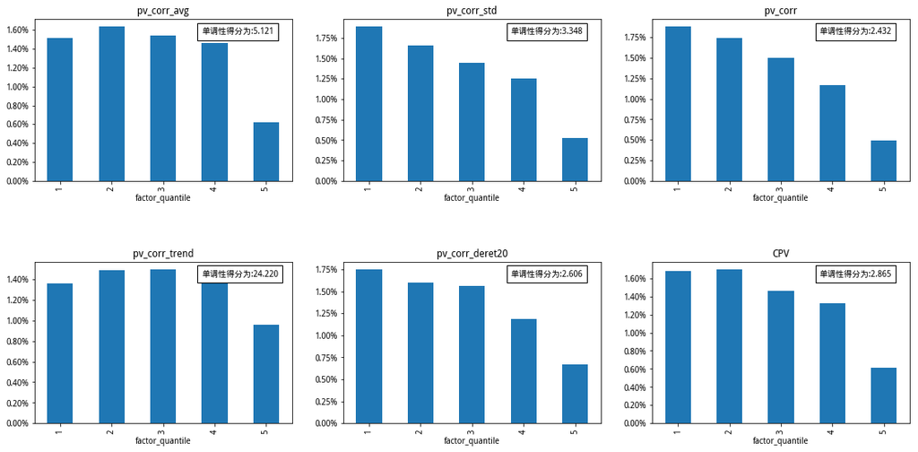

```python
# 因子分组平均收益
fig, axes = plt.subplots(2, 3, figsize=(19, 9))
axes = [i for x in axes for i in x]
for ax, (k, v) in zip(axes, res_dic.items()):

    mono_score = calc_mono_score(v.group_returns)
    ax.yaxis.set_major_formatter(
        mpl.ticker.FuncFormatter(lambda x, pos: '%.2f%%' % (x * 100)))
    ax.text(0.65,0.95,"单调性得分为:%.3f"%mono_score,
           fontsize=10,
           bbox={'facecolor': 'white', 'alpha': 1, 'pad': 5},
           transform=ax.transAxes,
           verticalalignment='top')
    v.group_returns.mean().plot.bar(ax=ax, title=k, color='#1f77b4')

plt.subplots_adjust(hspace=0.5)
```

由于 A股市场中做空手段相对有限,所以我们将重心放在多头组的分析中,从上图中可以看到第一组的收益相对较好，分别查看第一组每年的收益情况:

```python
# report
ret_by_y = pd.DataFrame(columns=list(res_dic.keys()))
ic_df = pd.DataFrame(columns=list(res_dic.keys()))
risk_df = pd.DataFrame(columns=list(res_dic.keys()))
for k, v in res_dic.items():

    ret_by_y[k] = v.group_returns[1].groupby(pd.Grouper(
        level=0, freq='Y')).apply(lambda x: ep.cum_returns(x)[-1])

    ic_df[k] = get_information_table(
        perf.factor_information_coefficient(v.factors_frame)).iloc[:, 0]
    risk_df[k] = get_performance_table(v.group_returns[[1]],
                                       periods='monthly').iloc[:, 0]

ret_by_y.index = ret_by_y.index.strftime('%Y')
ret_by_y.index.names = ['年度']

ret_by_y.style.format('{:.2%}').bar(align='mid', color=['#5fba7d', '#d65f5f'])
```

| 年度 | pv_corr_avg | pv_corr_std | pv_corr | pv_corr_trend | pv_corr_deret20 | CPV |
| --- | --- | --- | --- | --- | --- | --- |
| 2014 | 53.73% | 68.62% | 65.39% | 55.99% | 57.22% | 59.41% |
| 2015 | 19.73% | 37.41% | 34.34% | 19.30% | 41.24% | 37.34% |
| 2016 | 30.70% | 35.17% | 34.28% | 28.65% | 32.54% | 33.58% |
| 2017 | -10.25% | -9.13% | -8.39% | -14.62% | -12.38% | -11.76% |
| 2018 | -22.41% | -22.85% | -21.41% | -29.72% | -24.58% | -25.94% |
| 2019 | 30.71% | 28.41% | 31.11% | 38.70% | 30.40% | 32.82% |
| 2020 | 8.34% | 12.23% | 12.18% | 5.41% | 10.65% | 8.14% |
| 2021 | 24.46% | 35.39% | 32.15% | 24.95% | 29.57% | 25.27% |

```python
risk_df.style.format('{:.2%}').highlight_max(axis=1, color='#d65f5f')
```

|  | pv_corr_avg | pv_corr_std | pv_corr | pv_corr_trend | pv_corr_deret20 | CPV |
| --- | --- | --- | --- | --- | --- | --- |
| 年化收益率 | 14.82% | 20.41% | 20.01% | 13.11% | 17.91% | 17.08% |
| 累计收益 | 195.24% | 328.40% | 317.44% | 162.43% | 263.53% | 243.90% |
| 波动率 | 29.51% | 28.45% | 29.27% | 28.22% | 30.25% | 29.53% |
| 夏普 | 61.59% | 79.62% | 77.07% | 57.74% | 69.47% | 68.08% |
| 最大回撤 | -44.81% | -36.93% | -38.73% | -50.95% | -41.85% | -42.17% |

```python
# IC统计
ic_df
```

|  | pv_corr_avg | pv_corr_std | pv_corr | pv_corr_trend | pv_corr_deret20 | CPV |
| --- | --- | --- | --- | --- | --- | --- |
| IC Mean | -0.046 | -0.069 | -0.076 | -0.018 | -0.050 | -0.048 |
| IC Std. | 0.068 | 0.076 | 0.068 | 0.042 | 0.054 | 0.050 |
| Risk-Adjusted IC | -0.680 | -0.908 | -1.113 | -0.431 | -0.918 | -0.957 |
| t-stat(IC) | -6.589 | -8.800 | -10.794 | -4.180 | -8.905 | -9.274 |
| p-value(IC) | 0.000 | 0.000 | 0.000 | 0.000 | 0.000 | 0.000 |
| IC Skew | -0.491 | 0.437 | 0.267 | 0.114 | -0.169 | 0.405 |
| IC Kurtosis | 1.192 | 0.667 | 0.008 | 0.216 | 0.782 | 0.333 |

# 总结

本篇报告从技术分析中最简单的价量关系入手，在计算股票每日高频价量相关系数 的基础上，逐步挖掘了其中蕴藏的选股因子。

首先，我们定义了价量相关性的**平均数因子**和**波动性因子**。研究发现，两者其实都可以看做是对传统反转因子的修正。平均数因子认为，股票的月度行情是否反转需要看成交量的信息，若有量的确认，则月度行情的反转效应更强；而若没有量的确认，则月度行情更容易呈现动量效应。波动性因子则不论股票过去价格的涨跌，只要每日价量关 系维持稳定形态，下个月就更有可能上涨；而价量关系在多种形态间频繁转换的股票，下个月更有可能下跌。

其次，我们发现股票价量相关性的变化趋势也具有不错的选股能力，因此定义了**趋势因子**。回测结果显示，上个月的趋势因子值越小，即价量相关系数随时间推移逐渐变小的股票，下个月的收益倾向于越高，这与平均数因子的选股逻辑相呼应。